# CIFAR10-Lab

### **Quick introduction to jupyter notebooks**

- Each cell in this notebook contains either code or text.
- You can run a cell by pressing Ctrl-Enter, or run and advance to the next cell with Shift-Enter.
- Code cells will print their output, including images, below the cell. Running it again deletes the previous output, so be careful if you want to save some results.
- You don't have to rerun all cells to test changes, just rerun the cell you have made changes to. Some exceptions might apply, for example if you overwrite variables from previous cells, but in general this will work.
- If all else fails, use the "Kernel" menu and select "Restart Kernel and Clear All Output". You can also use this menu to run all cells.
- A useful debug tool is the console. You can right-click anywhere in the notebook and select "New console for notebook". This opens a python console which shares the environment with the notebook, which let's you easily print variables or test commands.

### **Setup**

```python
import os
import tensorflow as tf

# If there are multiple GPUs and we only want to use one/some, set the number in the visible device list.
os.environ["CUDA_DEVICE_ORDER"]="PCI_BUS_ID"
os.environ["CUDA_VISIBLE_DEVICES"]="0"

# This sets the GPU to allocate memory only as needed
physical_devices = tf.config.experimental.list_physical_devices('GPU')
if len(physical_devices) != 0:
    tf.config.experimental.set_memory_growth(physical_devices[0], True)
```

[output not shown]

### **1. Loading the dataset**

This assignment will focus on the CIFAR10 dataset. This is a collection of small images in 10 classes such as cars, cats, birds, etc. You can find more information here: https://www.cs.toronto.edu/~kriz/cifar.html. We start by loading and examining the data.

```python
import numpy as np
from tensorflow.keras.datasets import cifar10

(X_train, y_train), (X_test, y_test) = cifar10.load_data()

print("Shape of training data:")
print(X_train.shape)
print(y_train.shape)
print("Shape of test data:")
print(X_test.shape)
print(y_test.shape)
```

```
Shape of training data:
(50000, 32, 32, 3)
(50000, 1)
Shape of test data:
(10000, 32, 32, 3)
(10000, 1)
```

#### **Question 1:**

The shape of X_train and X_test has 4 values. What do each of these represent?

#### **Answer:**

Each row contains of the input data contains 32 arrays, which in turn contain 32 arrays of size 3 arrays which represent the RGB channel values for each pixel.

##### **Plotting some images**

This plots a random selection of images from each class. Rerun the cell to see a different selection.

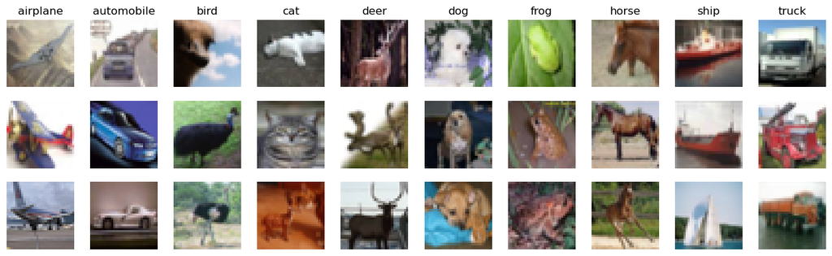

```python
from Custom import PlotRandomFromEachClass

cifar_labels = ['airplane', 'automobile', 'bird', 'cat', 'deer', 'dog', 'frog', 'horse', 'ship', 'truck']
PlotRandomFromEachClass(X_train, y_train, 3, labels=cifar_labels)
```

##### **Preparing the dataset**

Just like the MNIST dataset we normalize the images to [0,1] and transform the class indices to one-hot encoded vectors.

```python
from tensorflow.keras.utils import to_categorical

# Transform label indices to one-hot encoded vectors
y_train_c = to_categorical(y_train, num_classes=10)
y_test_c  = to_categorical(y_test , num_classes=10)

# Normalization of pixel values (to [0-1] range)
X_train = X_train.astype('float32') / 255
X_test  = X_test.astype('float32')  / 255
```

```python
# from tensorflow.keras.optimizers import SGD
# from tensorflow.keras.models import Model
# from tensorflow.keras.layers import Input, Dense, Flatten
# x_in = Input(shape=X_train.shape[1:])
# x = Flatten()(x_in)
# x
```

### **2. Fully connected classifier**

We will start by creating a fully connected classifier using the `Dense` layer. We give you the first layer that flattens the image features to a single vector. Add the remaining layers to the network.

Consider what the size of the output must be and what activation function you should use in the output layer.

```python
from tensorflow.keras.optimizers import SGD
from tensorflow.keras.models import Model
from tensorflow.keras.layers import Input, Dense, Flatten

x_in = Input(shape=X_train.shape[1:])
x = Flatten()(x_in)

# --------------------------------------------
# === Your code here =========================
# --------------------------------------------
x = Dense(40, activation='sigmoid')(x)
# x = Dense(25, activation='sigmoid')(x)
x = Dense(10, activation='softmax')(x)

# ============================================

model = Model(inputs=x_in, outputs=x)

# Now we build the model using Stochastic Gradient Descent with Nesterov momentum. We use accuracy as the metric.
sgd = SGD(learning_rate=0.01, decay=1e-6, momentum=0.9, nesterov=True)
model.compile(optimizer=sgd, loss='categorical_crossentropy', metrics=['accuracy'])
model.summary(100)
```

```
Model: "model_3"
____________________________________________________________________________________________________
Layer (type)                                 Output Shape                            Param #
====================================================================================================
input_4 (InputLayer)                         [(None, 32, 32, 3)]                     0
____________________________________________________________________________________________________
flatten_3 (Flatten)                          (None, 3072)                            0
____________________________________________________________________________________________________
dense_6 (Dense)                              (None, 40)                              122920
____________________________________________________________________________________________________
dense_7 (Dense)                              (None, 10)                              410
====================================================================================================
Total params: 123,330
Trainable params: 123,330
Non-trainable params: 0
____________________________________________________________________________________________________
```

##### **Training the model**

In order to show the differences between models in the first parts of the assignment, we will restrict the training to the following command using 15 epochs, batch size 32, and 20% validation data. From section 5 and forward you can change this as you please to increase the accuracy, but for now stick with this command.

```python
history = model.fit(X_train,y_train_c, epochs=15, batch_size=32, verbose=1, validation_split=0.2)
```

##### **Evaluating the model**

We use `model.evaluate` to get the loss and metric scores on the test data. To plot the results we give you a custom function that does the work for you.

```python
score = model.evaluate(X_test, y_test_c, batch_size=128, verbose=0)

for i in range(len(score)):
    print("Test " + model.metrics_names[i] + " = %.3f" % score[i])
```

```
Test loss = 1.501
Test accuracy = 0.466
```

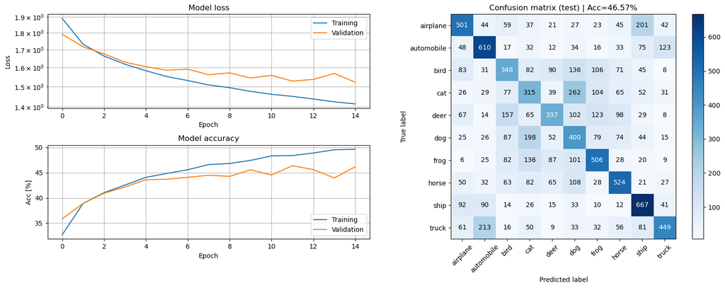

```python
from Custom import PlotModelEval

# Custom function for evaluating the model and plotting training history
PlotModelEval(model, history, X_test, y_test, cifar_labels)
```

#### **Question 2:**

Train a model that achieves above 45% accuracy on the test data. Provide a (short) motivation of your model architecture and briefly discuss the results.

#### **Answer:**

We also tried increasing the number of hidden layers by capping the nodes at 15, but the expected accuracy was not being achieved.

#### **Question 3:**

Compare this model to the one you used for the MNIST dataset in the first assignment, in terms of size and test accuracy. Why do you think this dataset is much harder to classify than the MNIST handwritten digits?

#### **Answer:**

- Number of features: The MNIST dataset had 5620 dataset with only 64 features (2-D data with 8x8 pixel values for each image) and hence we managed to achieve 93% accuracy. But in this case we have 50000 data samples, where each image is represented by 32x32 pixel values across 3 channels, meaning that we have 3072 features, which makes it a very high dimensional and complicated dataset.
- Problem complexity: In MNIST dataset, we have grey-scale handwritten digits(1 channel), while in CIFAR10, we have real-world images of objects that are defined by rgb scale(3 channels). This makes the classification more complex.

### **3. CNN classifier**

We will now move on to a network architecture that is more suited for this problem, the convolutional neural network. The new layers you will use are `Conv2D` and `MaxPooling2D`, which you can find the documentation of here https://www.tensorflow.org/api_docs/python/tf/keras/layers/Conv2D and here https://www.tensorflow.org/api_docs/python/tf/keras/layers/MaxPool2D.

##### **Creating the CNN model**

A common way to build convolutional neural networks is to create blocks of layers of the form **[convolution - activation - pooling]**, and then stack several of these block to create the full convolution stack. This is often followed by a fully connected network to create the output classes. Use this recipe to build a CNN that acheives at least 62% accuracy on the test data.

*Side note. Although this is a common way to build CNNs, it is be no means the only or even best way. It is a good starting point, but later in part 5 you might want to explore other architectures to acheive even better performance.*

```python
def convolution_nn(filters, input_layer):
#     x = Conv2D(filters, (5,5), activation='relu', input_shape = (32, 32, 3))(input_layer)
#     x = Conv2D(filters, (5,5), activation='relu', input_shape = (32, 32, 3))(x)
    x = Conv2D(filters, (4,4), activation='relu', padding='same')(input_layer)#can we remove the activation here?
    x = Conv2D(filters, (4,4), activation='relu', padding='same')(x)
    x = MaxPooling2D(pool_size=(2, 2))(x)
    return x
```

```python
from tensorflow.keras.layers import Conv2D, MaxPooling2D

x_in = Input(shape=X_train.shape[1:])

# --------------------------------------------
# === Your code here =========================
# --------------------------------------------
block1 = convolution_nn(10, x_in)
block2 = convolution_nn(20, block1)
block3 = convolution_nn(30, block2)
# x = convolution_nn(128, x)

# x = Conv2D(32, (4,4), activation='relu', input_shape = (32, 32, 3))(x_in)
# x = Conv2D(32, (4,4), activation='relu', input_shape = (32, 32, 3))(x)
# x = MaxPooling2D(pool_size=(2, 2))(x)

y = Flatten()(block3)

y = Dense(15, activation='relu')(y)
# x = Dense(25, activation='sigmoid')(x)
y = Dense(10, activation='softmax')(y)
# ============================================

model = Model(inputs=x_in, outputs=y)

sgd = SGD(learning_rate=0.01, decay=1e-6, momentum=0.9, nesterov=True)
model.compile(loss='categorical_crossentropy', metrics=['accuracy'], optimizer=sgd)
model.summary(100)
```

```
Model: "model_4"
____________________________________________________________________________________________________
Layer (type)                                 Output Shape                            Param #
====================================================================================================
input_7 (InputLayer)                         [(None, 32, 32, 3)]                     0
____________________________________________________________________________________________________
conv2d (Conv2D)                              (None, 32, 32, 10)                      490
____________________________________________________________________________________________________
conv2d_1 (Conv2D)                            (None, 32, 32, 10)                      1610
____________________________________________________________________________________________________
max_pooling2d (MaxPooling2D)                 (None, 16, 16, 10)                      0
____________________________________________________________________________________________________
conv2d_2 (Conv2D)                            (None, 16, 16, 20)                      3220
____________________________________________________________________________________________________
conv2d_3 (Conv2D)                            (None, 16, 16, 20)                      6420
____________________________________________________________________________________________________
max_pooling2d_1 (MaxPooling2D)               (None, 8, 8, 20)                        0
____________________________________________________________________________________________________
conv2d_4 (Conv2D)                            (None, 8, 8, 30)                        9630
____________________________________________________________________________________________________
conv2d_5 (Conv2D)                            (None, 8, 8, 30)                        14430
____________________________________________________________________________________________________
max_pooling2d_2 (MaxPooling2D)               (None, 4, 4, 30)                        0
____________________________________________________________________________________________________
flatten_4 (Flatten)                          (None, 480)                             0
____________________________________________________________________________________________________
dense_8 (Dense)                              (None, 15)                              7215
____________________________________________________________________________________________________
dense_9 (Dense)                              (None, 10)                              160
====================================================================================================
Total params: 43,175
Trainable params: 43,175
Non-trainable params: 0
____________________________________________________________________________________________________
```

##### **Training the CNN**

```python
history = model.fit(X_train, y_train_c, batch_size=32, epochs=15, verbose=1, validation_split=0.2)
```

[output not shown]

##### **Evaluating the CNN**

```python
score = model.evaluate(X_test, y_test_c, batch_size=128, verbose=0)

for i in range(len(score)):
    print("Test " + model.metrics_names[i] + " = %.3f" % score[i])
```

```
Test loss = 0.997
Test accuracy = 0.669
```

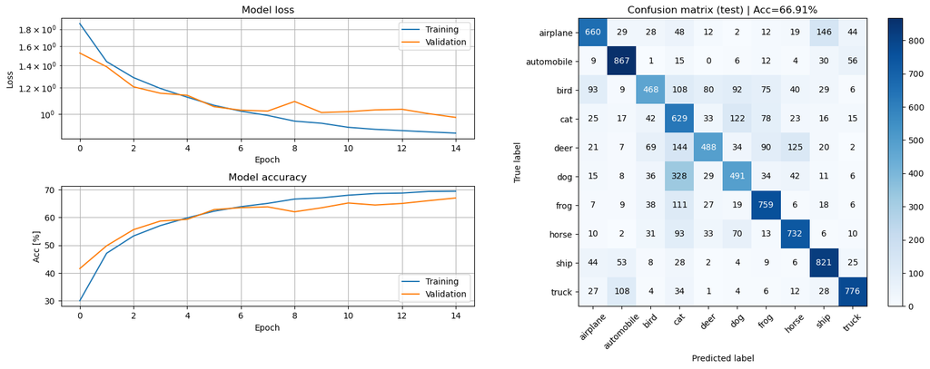

```python
PlotModelEval(model, history, X_test, y_test, cifar_labels)
```

#### **Question 4:**

Train a model that achieves at least 62% test accuracy. Provide a (short) motivation of your model architecture and briefly discuss the results.

#### **Question 5:**

Compare this model with the previous fully connected model. You should find that this one is much more efficient, i.e. achieves higher accuracy with fewer parameters. Explain in your own words how this is possible.

### **4. Regularization**

#### **4.1 Dropout**

You have probably seen that your CNN model overfits the training data. One way to prevent this is to add `Dropout` layers to the model, that randomly "drops" hidden nodes each training-iteration by setting their output to zero. Thus the model cannot rely on a small set of very good hidden features, but must instead learns to use different sets of hidden features each time. Dropout layers are usually added after the pooling layers in the convolution part of the model, or after activations in the fully connected part of the model.

*Side note. In the next assignment you will work with Ensemble models, a way to use the output from several individual models to achieve higher performance than each model can achieve on its own. One way to interpret Dropout is that each random selection of nodes is a separate model that is trained only on the current iteration. The final output is then the average of outputs from all the individual models. In other words, Dropout can be seen as a way to build ensembling directly into the network, without having to train several models explicitly.*

Extend your previous model with the Dropout layer and test the new performance.

```python
from tensorflow.keras.layers import Dropout

x_in = Input(shape=X_train.shape[1:])

# --------------------------------------------
# === Your code here =========================
# --------------------------------------------
block1 = convolution_nn(10, x_in)
block2 = convolution_nn(20, block1)
block3 = convolution_nn(30, block2)
# x = convolution_nn(128, x)

# x = Conv2D(32, (4,4), activation='relu', input_shape = (32, 32, 3))(x_in)
# x = Conv2D(32, (4,4), activation='relu', input_shape = (32, 32, 3))(x)
# x = MaxPooling2D(pool_size=(2, 2))(x)

y = Flatten()(block3)

y = Dense(15, activation='relu')(y)
y = Dropout(0.3)(y)
# x = Dense(25, activation='sigmoid')(x)
y = Dense(10, activation='softmax')(y)
# ============================================

model = Model(inputs=x_in, outputs=y)

# Compile model
sgd = SGD(learning_rate=0.01, decay=1e-6, momentum=0.9, nesterov=True)
model.compile(loss='categorical_crossentropy', metrics=['accuracy'], optimizer=sgd)
model.summary(100)
```

```
Model: "model_5"
____________________________________________________________________________________________________
Layer (type)                                 Output Shape                            Param #
====================================================================================================
input_8 (InputLayer)                         [(None, 32, 32, 3)]                     0
____________________________________________________________________________________________________
conv2d_6 (Conv2D)                            (None, 32, 32, 10)                      490
____________________________________________________________________________________________________
conv2d_7 (Conv2D)                            (None, 32, 32, 10)                      1610
____________________________________________________________________________________________________
max_pooling2d_3 (MaxPooling2D)               (None, 16, 16, 10)                      0
____________________________________________________________________________________________________
conv2d_8 (Conv2D)                            (None, 16, 16, 20)                      3220
____________________________________________________________________________________________________
conv2d_9 (Conv2D)                            (None, 16, 16, 20)                      6420
____________________________________________________________________________________________________
max_pooling2d_4 (MaxPooling2D)               (None, 8, 8, 20)                        0
____________________________________________________________________________________________________
conv2d_10 (Conv2D)                           (None, 8, 8, 30)                        9630
____________________________________________________________________________________________________
conv2d_11 (Conv2D)                           (None, 8, 8, 30)                        14430
____________________________________________________________________________________________________
max_pooling2d_5 (MaxPooling2D)               (None, 4, 4, 30)                        0
____________________________________________________________________________________________________
flatten_5 (Flatten)                          (None, 480)                             0
____________________________________________________________________________________________________
dense_10 (Dense)                             (None, 15)                              7215
____________________________________________________________________________________________________
dropout (Dropout)                            (None, 15)                              0
____________________________________________________________________________________________________
dense_11 (Dense)                             (None, 10)                              160
====================================================================================================
Total params: 43,175
Trainable params: 43,175
Non-trainable params: 0
____________________________________________________________________________________________________
```

```python
history = model.fit(X_train, y_train_c, batch_size=32, epochs=15, verbose=1, validation_split=0.2)
```

```python
score = model.evaluate(X_test, y_test_c, batch_size=128, verbose=0)

for i in range(len(score)):
    print("Test " + model.metrics_names[i] + " = %.3f" % score[i])
```

```
Test loss = 1.130
Test accuracy = 0.605
```

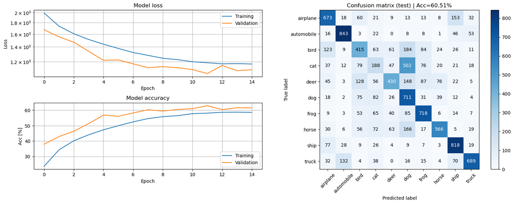

```python
PlotModelEval(model, history, X_test, y_test, cifar_labels)
```

#### **Question 6:**

Compare this model and the previous in terms of the training accuracy, validation accuracy, and test accuracy. Explain the similarities and differences (remember that the only difference between the models should be the addition of Dropout layers).

Hint: what does the dropout layer do at test time?

#### **Answer:**

- Comparision with respect to Training, Validation and Test accuracies:
  - Accuracy Model1 vs Model2: We can see that the accuracies after regularization has decreased as compared to previous model because in each epoch we are turning off 30% of the nodes which means that we have lesser parameters and hence reduced accuracies which is due to the regularizing effect.
  - In the previous model, based on the trend in the accuracies, we have observed that after initial epochs, the training accuracy is always higher than validation accuracy until the end of training and the test accuracy is in turn lower than that of validation accuracy which implies that the network is overfitting on the training data. However, in this model, we observe that for the most part of the training, the general trend is that validation accuracy is higher than training accuracy and finally we get a test accuracy that is in the range of validation accuracy which implies that the regularization has reduced the overfitting effect.
- Model Similarities and Differences:
  - Differences: The only difference in this model with respect to the previous model is that we have added a Dropout layer with a specified rate of dropout of the node outputs. We have included this layer after activation layer in the fully connected network.
  - Similarities: The Convolutional part of the network is the same as previous model with no changes. The fully connected network is also the same with the exception of a dropout layer.

#### **4.2 Batch normalization**

The final layer we will explore is `BatchNormalization`. As the name suggests, this layer normalizes the data in each batch to have a specific mean and standard deviation, which is learned during training. The reason for this is quite complicated (and still debated among the experts), but suffice to say that it helps the optimization converge faster which means we get higher performance in fewer epochs. The normalization is done separatly for each feature, i.e. the statistics are calculated accross the batch dimension of the input data. The equations for batch-normalizing one feature are the following, where $N$ is the batch size, $x$ the input features, and $y$ the normalized output features:

$$ \mu = \frac{1}{N} \sum_{i=0}^{N}x_i,\;\;\;\; \sigma^2 = \frac{1}{N} \sum_{i=0}^{N}(x_i - \mu)^2 $$$$ \hat{x}_i = \frac{x_i - \mu}{\sqrt{\sigma^2 + \epsilon}} $$$$ y_i = \gamma \hat{x}_i + \beta $$

At first glance this might look intimidating, but all it means is that we begin by scaling and shifting the data to have mean $\mu=0$ and standard deviation $\sigma=1$. After this we use the learnable parameters $\gamma$ and $\beta$ to decide the width and center of the final distribution. $\epsilon$ is a small constant value that prevents the denominator from being zero.

In addition to learning the parameters $\gamma$ and $\beta$ by gradient decent just like the weights, Batch Normalization also keeps track of the running average of minibatch statistics $\mu$ and $\sigma$. These averages are used to normalize the test data. We can tune the rate at which the running averages are updated with the *momentum* parameter of the BatchNormalization layer. A large momentum means that the statistics converge more slowly and therefore requires more updates before it represents the data. A low momentum, on the other hand, adapts to the data more quickly but might lead to unstable behaviour if the latest minibatches are not representative of the whole dataset. For this test we recommend a momentum of 0.75, but you probably want to change this when you design a larger network in Section 5.

The batch normalization layer should be added after the hidden layer linear transformation, but before the nonlinear activation. This means that we cannot specify the activation funciton in the `Conv2D` or `Dense` if we want to batch-normalize the output. We therefore need to use the `Activation` layer to add a separate activation to the network stack after batch normalization. For example, the convolution block will now look like **[conv - batchnorm - activation - pooling]**.

Extend your previous model with batch normalization, both in the convolution and fully connected part of the model.

```python
def convolution_nn_bn(filters, input_layer):
#     x = Conv2D(filters, (5,5), activation='relu', input_shape = (32, 32, 3))(input_layer)
#     x = Conv2D(filters, (5,5), activation='relu', input_shape = (32, 32, 3))(x)
    x = Conv2D(filters, (4,4), padding='same')(input_layer)#can we remove the activation here?
    x = BatchNormalization(momentum = 0.75)(x)
    x = Activation(activation='relu')(x)
    x = MaxPooling2D(pool_size=(2, 2))(x)
    return x
```

```python
from tensorflow.keras.layers import BatchNormalization, Activation

x_in = Input(shape=X_train.shape[1:])

# --------------------------------------------
# === Your code here =========================
# --------------------------------------------
block1 = convolution_nn_bn(10, x_in)
block2 = convolution_nn_bn(20, block1)
block3 = convolution_nn_bn(30, block2)

y = Flatten()(block3)

y = Dense(15)(y)
y = BatchNormalization(momentum = 0.75)(y)
y = Activation(activation='relu')(y)
y = Dropout(0.3)(y)

# x = Dense(25, activation='sigmoid')(x)
y = Dense(10, activation='softmax')(y)

# ============================================

model = Model(inputs=x_in, outputs=y)

sgd = SGD(learning_rate=0.01, decay=1e-6, momentum=0.9, nesterov=True)
model.compile(loss='categorical_crossentropy', metrics=['accuracy'], optimizer=sgd)
model.summary(100)
```

```
Model: "model_6"
____________________________________________________________________________________________________
Layer (type)                                 Output Shape                            Param #
====================================================================================================
input_9 (InputLayer)                         [(None, 32, 32, 3)]                     0
____________________________________________________________________________________________________
conv2d_12 (Conv2D)                           (None, 32, 32, 10)                      490
____________________________________________________________________________________________________
batch_normalization (BatchNormalization)     (None, 32, 32, 10)                      40
____________________________________________________________________________________________________
activation (Activation)                      (None, 32, 32, 10)                      0
____________________________________________________________________________________________________
max_pooling2d_6 (MaxPooling2D)               (None, 16, 16, 10)                      0
____________________________________________________________________________________________________
conv2d_13 (Conv2D)                           (None, 16, 16, 20)                      3220
____________________________________________________________________________________________________
batch_normalization_1 (BatchNormalization)   (None, 16, 16, 20)                      80
____________________________________________________________________________________________________
activation_1 (Activation)                    (None, 16, 16, 20)                      0
____________________________________________________________________________________________________
max_pooling2d_7 (MaxPooling2D)               (None, 8, 8, 20)                        0
____________________________________________________________________________________________________
conv2d_14 (Conv2D)                           (None, 8, 8, 30)                        9630
____________________________________________________________________________________________________
batch_normalization_2 (BatchNormalization)   (None, 8, 8, 30)                        120
____________________________________________________________________________________________________
activation_2 (Activation)                    (None, 8, 8, 30)                        0
____________________________________________________________________________________________________
max_pooling2d_8 (MaxPooling2D)               (None, 4, 4, 30)                        0
____________________________________________________________________________________________________
flatten_6 (Flatten)                          (None, 480)                             0
____________________________________________________________________________________________________
dense_12 (Dense)                             (None, 15)                              7215
____________________________________________________________________________________________________
batch_normalization_3 (BatchNormalization)   (None, 15)                              60
____________________________________________________________________________________________________
activation_3 (Activation)                    (None, 15)                              0
____________________________________________________________________________________________________
dropout_1 (Dropout)                          (None, 15)                              0
____________________________________________________________________________________________________
dense_13 (Dense)                             (None, 10)                              160
====================================================================================================
Total params: 21,015
Trainable params: 20,865
Non-trainable params: 150
____________________________________________________________________________________________________
```

```python
history = model.fit(X_train, y_train_c, batch_size=32, epochs=15, verbose=1, validation_split=0.2)
```

[output not shown]

```python
score = model.evaluate(X_test, y_test_c, batch_size=128, verbose=0)

for i in range(len(score)):
    print("Test " + model.metrics_names[i] + " = %.3f" % score[i])
```

```
Test loss = 0.890
Test accuracy = 0.692
```

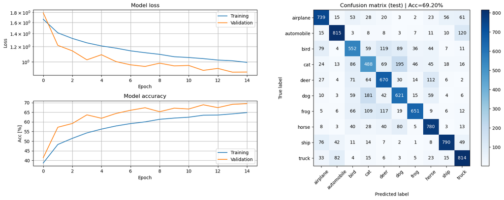

[output not shown]

```python
PlotModelEval(model, history, X_test, y_test, cifar_labels)
```

#### **Question 7:**

When using BatchNorm one must take care to select a good minibatch size. Describe what problems might arise if:

1. The minibatch size is too small.
2. The minibatch size is too large.

You can reason about this given the description of BatchNorm above, or you can search for the information in other sources. Do not forget to provide links to the sources if you do!

#### **Answer:**

When the batch size is high, the number of samples per iteration in an epoch reduces, and when the batch size is low, the number of samples per iteration in an epoch increases. It is always better to have good amount of samples per iteration, as the calculated mean and variance of the batch will be closer to the true population mean, variance, and this ensures more stabilized training.

### **5. Putting it all together**

We now want you to create your own model based on what you have learned. We want you to experiment and see what works and what doesn't, so don't go crazy with the number of epochs until you think you have something that works.

To pass this assignment, we want you to acheive **75%** accuracy on the test data in no more than **25 epochs**. This is possible using the layers and techniques we have explored in this notebook, but you are free to use any other methods that we didn't cover. (You are obviously not allowed to cheat, for example by training on the test data.)

```python
def convolution_nn_bn1(filters, input_layer):
    x = Conv2D(filters, (3,3), padding='same')(input_layer)#can we remove the activation here?
    x = BatchNormalization(momentum = 0.80)(x)
    x = Activation(activation='relu')(x)
    x = MaxPooling2D(pool_size=(2, 2))(x)
    return x
```

```python
from tensorflow.keras.layers import BatchNormalization, Activation, Add
def resnet(filters, input_layer):
    x = Conv2D(filters, (3,3), padding='same')(input_layer)#can we remove the activation here?
    x = BatchNormalization(momentum = 0.80)(x)
    x = Activation(activation='relu')(x)
    x = MaxPooling2D(pool_size=(2, 2))(x)

    x = Conv2D(filters, (3,3), padding='same')(x)
    x = BatchNormalization(momentum = 0.80)(x)

    skip = Conv2D(filters, (1,1), padding='same')(input_layer)
    x = Add()([x, skip])

    x = Activation(activation='relu')(x)
    x = MaxPooling2D(pool_size=(2, 2))(x)
    return x
```

```
Model: "model_4"
____________________________________________________________________________________________________
Layer (type)                                 Output Shape                            Param #
====================================================================================================
input_5 (InputLayer)                         [(None, 32, 32, 3)]                     0
____________________________________________________________________________________________________
conv2d_15 (Conv2D)                           (None, 32, 32, 64)                      1792
____________________________________________________________________________________________________
batch_normalization_1 (BatchNormalization)   (None, 32, 32, 64)                      256
____________________________________________________________________________________________________
activation_4 (Activation)                    (None, 32, 32, 64)                      0
____________________________________________________________________________________________________
max_pooling2d_9 (MaxPooling2D)               (None, 16, 16, 64)                      0
____________________________________________________________________________________________________
conv2d_16 (Conv2D)                           (None, 16, 16, 64)                      36928
____________________________________________________________________________________________________
batch_normalization_2 (BatchNormalization)   (None, 16, 16, 64)                      256
____________________________________________________________________________________________________
activation_5 (Activation)                    (None, 16, 16, 64)                      0
____________________________________________________________________________________________________
max_pooling2d_10 (MaxPooling2D)              (None, 8, 8, 64)                        0
____________________________________________________________________________________________________
conv2d_17 (Conv2D)                           (None, 8, 8, 64)                        36928
____________________________________________________________________________________________________
batch_normalization_3 (BatchNormalization)   (None, 8, 8, 64)                        256
____________________________________________________________________________________________________
activation_6 (Activation)                    (None, 8, 8, 64)                        0
____________________________________________________________________________________________________
max_pooling2d_11 (MaxPooling2D)              (None, 4, 4, 64)                        0
____________________________________________________________________________________________________
conv2d_18 (Conv2D)                           (None, 4, 4, 64)                        36928
____________________________________________________________________________________________________
batch_normalization_4 (BatchNormalization)   (None, 4, 4, 64)                        256
____________________________________________________________________________________________________
activation_7 (Activation)                    (None, 4, 4, 64)                        0
____________________________________________________________________________________________________
max_pooling2d_12 (MaxPooling2D)              (None, 2, 2, 64)                        0
____________________________________________________________________________________________________
flatten_4 (Flatten)                          (None, 256)                             0
____________________________________________________________________________________________________
dense_8 (Dense)                              (None, 30)                              7710
____________________________________________________________________________________________________
batch_normalization_5 (BatchNormalization)   (None, 30)                              120
____________________________________________________________________________________________________
activation_8 (Activation)                    (None, 30)                              0
____________________________________________________________________________________________________
dropout_2 (Dropout)                          (None, 30)                              0
____________________________________________________________________________________________________
dense_9 (Dense)                              (None, 10)                              310
====================================================================================================
Total params: 121,740
Trainable params: 121,168
Non-trainable params: 572
____________________________________________________________________________________________________
```

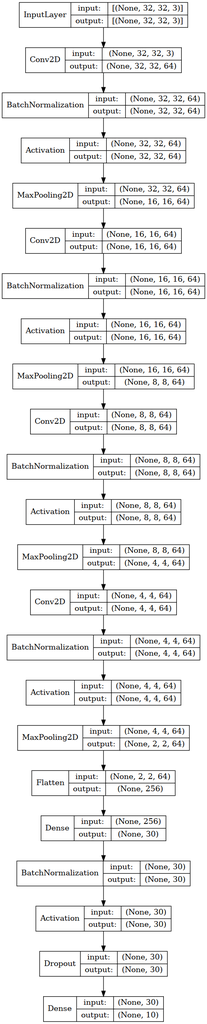

```python
from tensorflow.keras.utils import plot_model

x_in = Input(shape=X_train.shape[1:])

# --------------------------------------------
# === Your code here =========================
# --------------------------------------------
block1 = convolution_nn_bn1(64, x_in)
block2 = convolution_nn_bn1(64, block1)
block3 = convolution_nn_bn1(64, block2)
block4 = convolution_nn_bn1(64, block3)

y = Flatten()(block4)

y = Dense(30)(y)
y = BatchNormalization(momentum = 0.80)(y)
y = Activation(activation='relu')(y)
y = Dropout(0.5)(y)

# x = Dense(25, activation='sigmoid')(x)
y = Dense(10, activation='softmax')(y)

# ============================================

model = Model(inputs=x_in, outputs=y)

sgd = SGD(learning_rate=0.05, decay=1e-6, momentum=0.9, nesterov=True)
model.compile(loss='categorical_crossentropy', metrics=['accuracy'], optimizer=sgd)
model.summary(100)
plot_model(model, show_shapes=True, show_layer_names=False)
```

```python
history = model.fit(X_train, y_train_c, batch_size=16, epochs=25, verbose=1, validation_split=0.2)
```

```python
score = model.evaluate(X_test, y_test_c, batch_size=128, verbose=0)

for i in range(len(score)):
    print("Test " + model.metrics_names[i] + " = %.3f" % score[i])
```

```
Test loss = 0.718
Test accuracy = 0.760
```

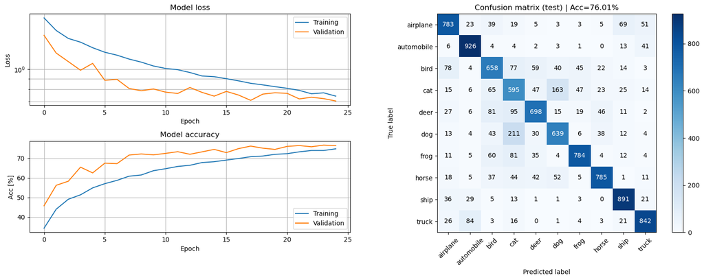

```python
from Custom import PlotModelEval
PlotModelEval(model, history, X_test, y_test, cifar_labels)
```

#### **Question 8:**

Design and train a model that achieves at least 75% test accuracy in at most 25 epochs. Explain your model architecture and motivate the design choices you have made.

#### **Answer:**

The model architecture is as follows:

### **Want some extra challenge?**

For those of you that want to get creative, here are some things to look into. But note that we don't have the answers here. Any of these might improve the performance, or might not, or it might only work in combination with each other. This is up to you to figure out. This is how deep learning research often happens, trying things in a smart way to see what works best.

- Tweak or change the optimizer or training parameters.
- Tweak the filter parameters, such as numbers and sizes of filters.
- Use other activation functions.
- Add L1/L2 regularization (see https://www.tensorflow.org/api_docs/python/tf/keras/regularizers)
- Include layers that we did not cover here (see https://www.tensorflow.org/api_docs/python/tf/keras/layers). For example, our best model uses the global pooling layers.
- Take inspiration from some well-known architectures, such as ResNet or VGG16. (But don't just copy-paste those architectures. For one, what's the fun in that? Also, they take a long time to train, you will not have time.)
- Use explicit model ensembing (training multiple models that vote on or average the outputs - this will also take a lot of time.)
- Use data augmentation to create a larger training set (see https://www.tensorflow.org/api_docs/python/tf/keras/preprocessing/image/ImageDataGenerator).

```python
from tensorflow.keras.layers import BatchNormalization, Activation, Add
def resnet_block(filters, input_layer):
    x = Conv2D(filters, (3,3), padding='same')(input_layer)
    x = BatchNormalization(momentum = 0.80)(x)
    x = Activation(activation='relu')(x)

    x = Conv2D(filters, (3,3), padding='same')(x)
    x = BatchNormalization(momentum = 0.80)(x)

    skip = Conv2D(filters, (1,1), padding='same')(input_layer)
    x = Add()([x, skip])

    x = Activation(activation='relu')(x)
    x = MaxPooling2D(pool_size=(2, 2), padding='same')(x)
    return x
```

```
Model: "model_7"
____________________________________________________________________________________________________
Layer (type)                     Output Shape          Param #     Connected to
====================================================================================================
input_10 (InputLayer)            [(None, 32, 32, 3)]   0
____________________________________________________________________________________________________
conv2d_15 (Conv2D)               (None, 32, 32, 30)    840         input_10[0][0]
____________________________________________________________________________________________________
batch_normalization_4 (BatchNorm (None, 32, 32, 30)    120         conv2d_15[0][0]
____________________________________________________________________________________________________
activation_4 (Activation)        (None, 32, 32, 30)    0           batch_normalization_4[0][0]
____________________________________________________________________________________________________
conv2d_16 (Conv2D)               (None, 32, 32, 30)    8130        activation_4[0][0]
____________________________________________________________________________________________________
batch_normalization_5 (BatchNorm (None, 32, 32, 30)    120         conv2d_16[0][0]
____________________________________________________________________________________________________
conv2d_17 (Conv2D)               (None, 32, 32, 30)    120         input_10[0][0]
____________________________________________________________________________________________________
add (Add)                        (None, 32, 32, 30)    0           batch_normalization_5[0][0]
                                                                   conv2d_17[0][0]
____________________________________________________________________________________________________
activation_5 (Activation)        (None, 32, 32, 30)    0           add[0][0]
____________________________________________________________________________________________________
max_pooling2d_9 (MaxPooling2D)   (None, 16, 16, 30)    0           activation_5[0][0]
____________________________________________________________________________________________________
conv2d_18 (Conv2D)               (None, 16, 16, 40)    10840       max_pooling2d_9[0][0]
____________________________________________________________________________________________________
batch_normalization_6 (BatchNorm (None, 16, 16, 40)    160         conv2d_18[0][0]
____________________________________________________________________________________________________
activation_6 (Activation)        (None, 16, 16, 40)    0           batch_normalization_6[0][0]
____________________________________________________________________________________________________
conv2d_19 (Conv2D)               (None, 16, 16, 40)    14440       activation_6[0][0]
____________________________________________________________________________________________________
batch_normalization_7 (BatchNorm (None, 16, 16, 40)    160         conv2d_19[0][0]
____________________________________________________________________________________________________
conv2d_20 (Conv2D)               (None, 16, 16, 40)    1240        max_pooling2d_9[0][0]
____________________________________________________________________________________________________
add_1 (Add)                      (None, 16, 16, 40)    0           batch_normalization_7[0][0]
                                                                   conv2d_20[0][0]
____________________________________________________________________________________________________
activation_7 (Activation)        (None, 16, 16, 40)    0           add_1[0][0]
____________________________________________________________________________________________________
max_pooling2d_10 (MaxPooling2D)  (None, 8, 8, 40)      0           activation_7[0][0]
____________________________________________________________________________________________________
flatten_7 (Flatten)              (None, 2560)          0           max_pooling2d_10[0][0]
____________________________________________________________________________________________________
dense_14 (Dense)                 (None, 30)            76830       flatten_7[0][0]
____________________________________________________________________________________________________
batch_normalization_8 (BatchNorm (None, 30)            120         dense_14[0][0]
____________________________________________________________________________________________________
activation_8 (Activation)        (None, 30)            0           batch_normalization_8[0][0]
____________________________________________________________________________________________________
dropout_2 (Dropout)              (None, 30)            0           activation_8[0][0]
____________________________________________________________________________________________________
dense_15 (Dense)                 (None, 10)            310         dropout_2[0][0]
====================================================================================================
Total params: 113,430
Trainable params: 113,090
Non-trainable params: 340
____________________________________________________________________________________________________
```

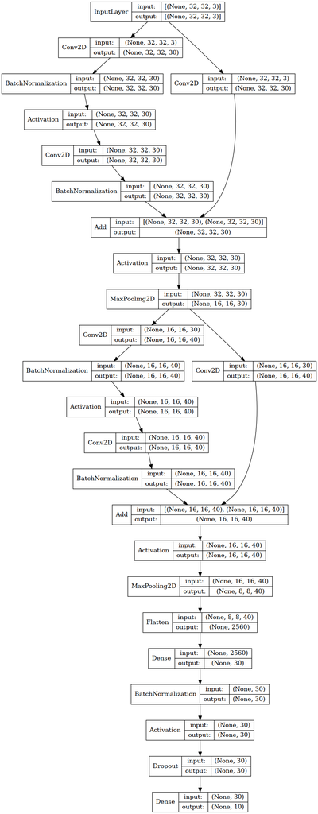

```python
from tensorflow.keras.utils import plot_model

x_in = Input(shape=X_train.shape[1:])

# --------------------------------------------
# === Your code here =========================
# --------------------------------------------
block1 = resnet_block(30, x_in)
block2 = resnet_block(40, block1)

y = Flatten()(block2)

y = Dense(30)(y)
y = BatchNormalization(momentum = 0.80)(y)
y = Activation(activation='relu')(y)
y = Dropout(0.5)(y)

# x = Dense(25, activation='sigmoid')(x)
y = Dense(10, activation='softmax')(y)

# ============================================

model = Model(inputs=x_in, outputs=y)

sgd = SGD(learning_rate=0.01, decay=1e-6, momentum=0.9, nesterov=True)
model.compile(loss='categorical_crossentropy', metrics=['accuracy'], optimizer=sgd)
model.summary(100)
plot_model(model, show_shapes=True, show_layer_names=False)
```

```python
history = model.fit(X_train, y_train_c, batch_size=32, epochs=20, verbose=1, validation_split=0.2)
```

```python
score = model.evaluate(X_test, y_test_c, batch_size=128, verbose=0)

for i in range(len(score)):
    print("Test " + model.metrics_names[i] + " = %.3f" % score[i])
```

```
Test loss = 0.715
Test accuracy = 0.758
```

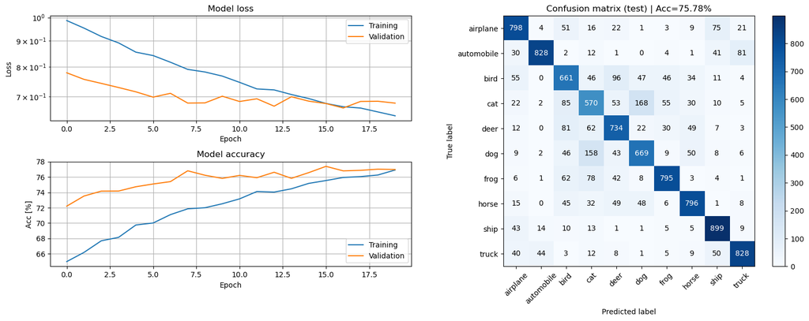

```python
PlotModelEval(model, history, X_test, y_test, cifar_labels)
```